# Project 2: Data Mining, Classification, Prediction

SDS322E

# Mining, Classification, Prediction

## Nelly Akhmadikina NA24752

### Introduction

I chose 3 data sets for my project. “pop1” is statistics on population of LGBT individuals in each US state including some territories. This dataset was take from the Movement Advancement Project (MAP) at https://www.lgbtmap.org/equality-maps/lgbt_populations. The variables I am using from this dataset are Total adult population (totaladpop), the LGBT Adult population(lgbtadpop), the LGBT population density (lgbtpopdensity), the Percent of Same-Sex individuals raising kids (percentindivkids), and the Percent of Same-Sex couples raising kids (percentcoupleskids). “policy1” is data on policies regarding the LGBT community. This data set includes the Sexual Orientation Policy tallies (SOpolicy) and Gender Identity Policy tallies (GIpolicy) that the Movement Advancement Project assigns to each states based on it helpful or harmful policies that are in place. The total of those two tallies is shown as Overall Tally (overallpolicy) . I will not be using any other variables from this dataset. This data is found on https://www.lgbtmap.org/equality-maps/. My third dataset “marriage1” is found on https://www.pewforum.org/religious-landscape-study/compare/views-about-same-sex-marriage/by/state/. It is from the Pew Research Center. This was a 2014 survey on Views about same-sex marriage by state. This dataset includes the percent who Favor(favormarriage), Oppose (opposemarriage), and Don’t Know (dkmarriage), as well as the sample size of the survey (marriagesample). I will not be using the sample size. I am interested in this data because I like studying statistics on the LGBT community. I wish to go into the public health sector to health the LGBT community. The dataset includes District of Columbia. I keep it in during most calculations, but I remove it when grouping by region. To create a classifier group I was curious which party each state voted for in the 2020 election, since it is a binary statistic. “statevotte” comes fromo https://www.archives.gov/electoral-college/2020. If a state voted democrat it is classified with a 1. If a state voted republican, then it is a 0. If a state split their vote, I entered it as which party got more of the votes.

```r
library(tidyverse)
# read in csvs
pop1 <- read_csv("LMS1.csv")
marriage1 <- read_csv("LGBT MAP - Sheet3.csv")
policy1 <- read_csv("LGBT MAP - Sheet2.csv")
statevote <- read_csv("statevote.csv")
# glimpse
glimpse(policy1)
```

```
## Rows: 112
## Columns: 13
## $ X1                                       <dbl> 1, NA, 2, NA, 3, NA, 4, NA, …
## $ State                                    <chr> "Alabama", NA, "Alaska", NA,…
## $ X3                                       <chr> "SO", "GI", "SO", "GI", "SO"…
## $ `RELATIONSHIP AND\nPARENTAL RECOGNITION` <chr> "1.5/6", "0/1", "2.5/6", "1/…
## $ `NON–DISCRIMINATION`                     <chr> "0/4.5", "0/4.5", "3.5/4.5",…
## $ `RELIGIOUS EXEMPTION LAWS`               <chr> "-2.5/-3.5", "-2.5/-2.5", "0…
## $ `LGBT YOUTH`                             <chr> "0/4", "-1/4", "1.5/4", "1.5…
## $ HEALTHCARE                               <chr> "0.5/2", "0/4.5", "0.5/2", "…
## $ `CRIMINAL\nJUSTICE`                      <chr> "0/2", "0/2", "-0.25/2", "-0…
## $ `IDENTITY\nDOCUMENTS`                    <chr> "--", "0/4", "--", "1.75/4",…
## $ `SEXUAL ORIENTATION POLICY TALLY`        <dbl> -0.50, NA, 7.75, NA, 1.50, N…
## $ `GENDER IDENTITY POLICY TALLY`           <dbl> -3.50, NA, 9.00, NA, -1.00, …
## $ `OVERALL TALLY`                          <dbl> -4.00, NA, 16.75, NA, 0.50, …
```

```r
glimpse(marriage1)
```

```
## Rows: 51
## Columns: 5
## $ State                                      <chr> "Alabama", "Alaska", "Ariz…
## $ `Strongly favor/favor same-sex marriage`   <chr> "33%", "59%", "56%", "35%"…
## $ `Oppose/strongly oppose same-sex marriage` <chr> "57%", "34%", "36%", "53%"…
## $ `Don't know, same-sex marriage`            <chr> "10%", "6%", "8%", "12%", …
## $ `Sample Size, same-sex marriage`           <dbl> 511, 310, 653, 311, 3697, …
```

```r
glimpse(pop1)
```

```
## Rows: 56
## Columns: 6
## $ STATE                                     <chr> "ALABAMA", "ALASKA", "AMERI…
## $ `TOTAL ADULT POPULATION`                  <dbl> 4887871, 737438, 55519, 717…
## $ `LGBT ADULT POPULATION`                   <chr> "147,000", "25,000", "N/A",…
## $ `LGBT POPULATION DENSITY`                 <chr> "3.10%", "3.70%", "N/A", "4…
## $ `% OF LGBTQ INDIVIDUALS RAISING CHILDREN` <chr> "24.00%", "34.00%", "N/A", …
## $ `% OF SAME-SEX COUPLES RAISING CHILDREN`  <chr> "20.40%", "23.10%", "N/A", …
```

```r
# tidying
policy <- policy1 %>% na.omit
marrmess <- marriage1 %>% pivot_longer(2:4)
head(marrmess)
```

```
## # A tibble: 6 x 4
##   State   `Sample Size, same-sex marri… name                               value
##   <chr>                           <dbl> <chr>                              <chr>
## 1 Alabama                           511 Strongly favor/favor same-sex mar… 33%
## 2 Alabama                           511 Oppose/strongly oppose same-sex m… 57%
## 3 Alabama                           511 Don't know, same-sex marriage      10%
## 4 Alaska                            310 Strongly favor/favor same-sex mar… 59%
## 5 Alaska                            310 Oppose/strongly oppose same-sex m… 34%
## 6 Alaska                            310 Don't know, same-sex marriage      6%
```

```r
marriage <- marrmess %>% pivot_wider(names_from = name, values_from = value)
marriage <- marriage %>% mutate(State = tolower(State))
head(marriage)
```

```
## # A tibble: 6 x 5
##   State  `Sample Size, sa… `Strongly favor/f… `Oppose/strongly… `Don't know, sa…
##   <chr>              <dbl> <chr>              <chr>             <chr>
## 1 alaba…               511 33%                57%               10%
## 2 alaska               310 59%                34%               6%
## 3 arizo…               653 56%                36%               8%
## 4 arkan…               311 35%                53%               12%
## 5 calif…              3697 62%                32%               6%
## 6 color…               504 62%                31%               7%
```

```r
pop <- pop1 %>% rename(State = "STATE") %>% mutate(State = tolower(State))
policy <- policy %>% mutate(State = tolower(State))
# joins
poppolicy <- full_join(pop, policy)
lgbt1 <- right_join(poppolicy, marriage)
# democrat is 1 and republican is 0 in 'statevote'
lgbt2 <- full_join(lgbt1, statevote)
glimpse(lgbt2)
```

```
## Rows: 51
## Columns: 23
## $ State                                      <chr> "alabama", "alaska", "ariz…
## $ `TOTAL ADULT POPULATION`                   <dbl> 4887871, 737438, 7171646, …
## $ `LGBT ADULT POPULATION`                    <chr> "147,000", "25,000", "286,…
## $ `LGBT POPULATION DENSITY`                  <chr> "3.10%", "3.70%", "4.50%",…
## $ `% OF LGBTQ INDIVIDUALS RAISING CHILDREN`  <chr> "24.00%", "34.00%", "25.00…
## $ `% OF SAME-SEX COUPLES RAISING CHILDREN`   <chr> "20.40%", "23.10%", "16.50…
## $ X1                                         <dbl> 1, 2, 4, 5, 6, 7, 8, 9, 10…
## $ X3                                         <chr> "SO", "SO", "SO", "SO", "S…
## $ `RELATIONSHIP AND\nPARENTAL RECOGNITION`   <chr> "1.5/6", "2.5/6", "2.5/6",…
## $ `NON–DISCRIMINATION`                       <chr> "0/4.5", "3.5/4.5", "1.75/…
## $ `RELIGIOUS EXEMPTION LAWS`                 <chr> "-2.5/-3.5", "0/-3.5", "-0…
## $ `LGBT YOUTH`                               <chr> "0/4", "1.5/4", "0/4", "0/…
## $ HEALTHCARE                                 <chr> "0.5/2", "0.5/2", "1/2", "…
## $ `CRIMINAL\nJUSTICE`                        <chr> "0/2", "-0.25/2", "1/2", "…
## $ `IDENTITY\nDOCUMENTS`                      <chr> "--", "--", "--", "--", "-…
## $ `SEXUAL ORIENTATION POLICY TALLY`          <dbl> -0.50, 7.75, 5.75, -0.50, …
## $ `GENDER IDENTITY POLICY TALLY`             <dbl> -3.50, 9.00, -0.50, -5.00,…
## $ `OVERALL TALLY`                            <dbl> -4.00, 16.75, 5.25, -5.50,…
## $ `Sample Size, same-sex marriage`           <dbl> 511, 310, 653, 311, 3697, …
## $ `Strongly favor/favor same-sex marriage`   <chr> "33%", "59%", "56%", "35%"…
## $ `Oppose/strongly oppose same-sex marriage` <chr> "57%", "34%", "36%", "53%"…
## $ `Don't know, same-sex marriage`            <chr> "10%", "6%", "8%", "12%", …
## $ Party20                                    <dbl> 0, 0, 1, 0, 1, 1, 1, 1, 1,…
```

```r
# renaming columns to easier and shorter names to type,
# removing unwanted columns
lgbt3 <- lgbt2 %>% rename(marriagesample = "Sample Size, same-sex marriage",
    favormarriage = "Strongly favor/favor same-sex marriage",
    opposemarriage = "Oppose/strongly oppose same-sex marriage",
    dkmarriage = "Don't know, same-sex marriage", totaladpop = "TOTAL ADULT POPULATION",
    lgbtadpop = "LGBT ADULT POPULATION", lgbtpopdensity = "LGBT POPULATION DENSITY",
    percentindivkids = "% OF LGBTQ INDIVIDUALS RAISING CHILDREN",
    percentcoupleskids = "% OF SAME-SEX COUPLES RAISING CHILDREN",
    SOpolicy = "SEXUAL ORIENTATION POLICY TALLY", GIpolicy = "GENDER IDENTITY POLICY TALLY",
    overallpolicy = "OVERALL TALLY")
lgbt <- lgbt3 %>% select(1:6, 16:18, 20:21, 23)
glimpse(lgbt)
```

```
## Rows: 51
## Columns: 12
## $ State              <chr> "alabama", "alaska", "arizona", "arkansas", "calif…
## $ totaladpop         <dbl> 4887871, 737438, 7171646, 3013825, 39557045, 56955…
## $ lgbtadpop          <chr> "147,000", "25,000", "286,000", "95,000", "1,859,0…
## $ lgbtpopdensity     <chr> "3.10%", "3.70%", "4.50%", "3.30%", "5.30%", "4.60…
## $ percentindivkids   <chr> "24.00%", "34.00%", "25.00%", "36.00%", "24.00%", …
## $ percentcoupleskids <chr> "20.40%", "23.10%", "16.50%", "21.20%", "16.00%", …
## $ SOpolicy           <dbl> -0.50, 7.75, 5.75, -0.50, 16.50, 16.75, 16.50, 12.…
## $ GIpolicy           <dbl> -3.50, 9.00, -0.50, -5.00, 18.75, 18.75, 19.00, 12…
## $ overallpolicy      <dbl> -4.00, 16.75, 5.25, -5.50, 35.25, 35.50, 35.50, 25…
## $ favormarriage      <chr> "33%", "59%", "56%", "35%", "62%", "62%", "71%", "…
## $ opposemarriage     <chr> "57%", "34%", "36%", "53%", "32%", "31%", "26%", "…
## $ Party20            <dbl> 0, 0, 1, 0, 1, 1, 1, 1, 1, 0, 1, 1, 0, 1, 0, 0, 0,…
```

```r
# removing commas and percent signs in data
lgbt$lgbtadpop <- as.numeric(gsub(",", "", lgbt$lgbtadpop))
lgbt$lgbtpopdensity <- as.numeric(gsub("%", "", lgbt$lgbtpopdensity))
lgbt$percentindivkids <- as.numeric(gsub("%", "", lgbt$percentindivkids))
lgbt$percentcoupleskids <- as.numeric(gsub("%", "", lgbt$percentcoupleskids))
lgbt$favormarriage <- as.numeric(gsub("%", "", lgbt$favormarriage))
lgbt$opposemarriage <- as.numeric(gsub("%", "", lgbt$opposemarriage))
glimpse(lgbt)
```

```
## Rows: 51
## Columns: 12
## $ State              <chr> "alabama", "alaska", "arizona", "arkansas", "calif…
## $ totaladpop         <dbl> 4887871, 737438, 7171646, 3013825, 39557045, 56955…
## $ lgbtadpop          <dbl> 147000, 25000, 286000, 95000, 1859000, 234000, 133…
## $ lgbtpopdensity     <dbl> 3.1, 3.7, 4.5, 3.3, 5.3, 4.6, 3.9, 4.5, 9.8, 4.6, …
## $ percentindivkids   <dbl> 24, 34, 25, 36, 24, 25, 20, 35, 9, 24, 27, 30, 44,…
## $ percentcoupleskids <dbl> 20.4, 23.1, 16.5, 21.2, 16.0, 15.9, 17.0, 15.6, 8.…
## $ SOpolicy           <dbl> -0.50, 7.75, 5.75, -0.50, 16.50, 16.75, 16.50, 12.…
## $ GIpolicy           <dbl> -3.50, 9.00, -0.50, -5.00, 18.75, 18.75, 19.00, 12…
## $ overallpolicy      <dbl> -4.00, 16.75, 5.25, -5.50, 35.25, 35.50, 35.50, 25…
## $ favormarriage      <dbl> 33, 59, 56, 35, 62, 62, 71, 59, 64, 53, 45, 55, 49…
## $ opposemarriage     <dbl> 57, 34, 36, 53, 32, 31, 26, 36, 26, 38, 48, 33, 39…
## $ Party20            <dbl> 0, 0, 1, 0, 1, 1, 1, 1, 1, 0, 1, 1, 0, 1, 0, 0, 0,…
```

```r
lgbttest <- lgbt %>% select(-1, -12)
```

### Cluster Analysis

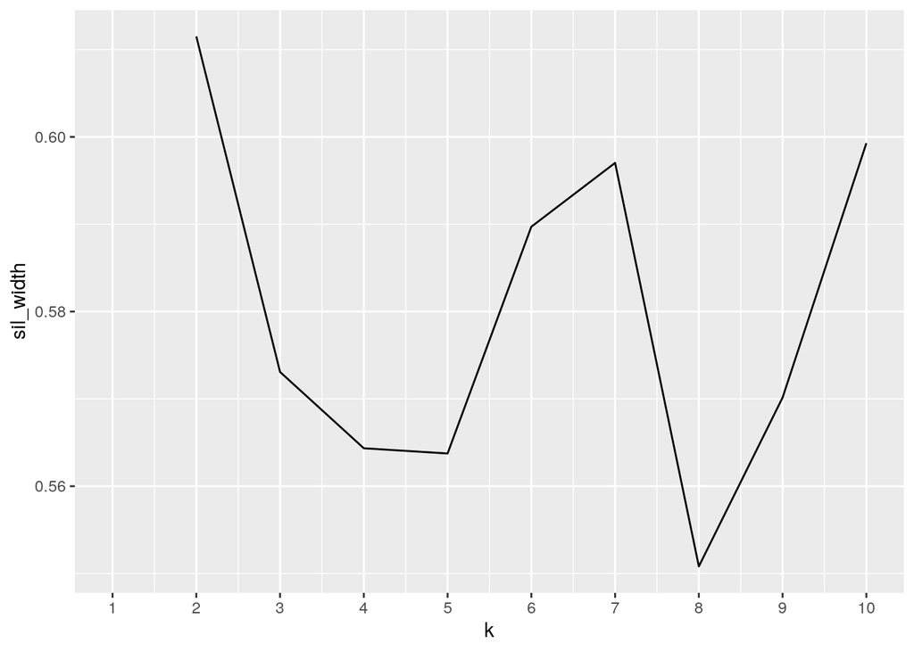

```r
library(cluster)
library(GGally)
# sil
sil_width <- vector()
for (i in 2:10) {
    pam_fit <- pam(lgbttest, k = i)
    sil_width[i] <- pam_fit$silinfo$avg.width
}
ggplot() + geom_line(aes(x = 1:10, y = sil_width)) + scale_x_continuous(name = "k",
    breaks = 1:10)
```

```r
#
pam1 <- lgbttest %>% scale %>% pam(k = 2)  #use the pam function
pam1
```

```
## Medoids:
##      ID totaladpop  lgbtadpop lgbtpopdensity percentindivkids
## [1,] 19 -0.2390026 -0.2688539     -0.2931620         0.131652
## [2,] 24 -0.1094696 -0.1417516     -0.1062712         0.131652
##      percentcoupleskids   SOpolicy  GIpolicy overallpolicy favormarriage
## [1,]          0.5557452 -1.2677654 -1.232028     -1.257305    -1.0579568
## [2,]         -0.5969607  0.9038251  1.100340      1.029184     0.6158544
##      opposemarriage
## [1,]      1.0947807
## [2,]     -0.3772973
## Clustering vector:
##  [1] 1 2 1 1 2 2 2 2 2 2 1 2 1 2 1 2 1 1 1 2 2 2 2 2 1 1 1 1 2 2 2 2 2 1 1 1 1 2
## [39] 2 2 1 1 1 1 1 2 2 2 1 2 1
## Objective function:
##    build     swap
## 2.412229 2.180443
##
## Available components:
##  [1] "medoids"    "id.med"     "clustering" "objective"  "isolation"
##  [6] "clusinfo"   "silinfo"    "diss"       "call"       "data"
```

```r
pam1$silinfo$avg.width
```

```
## [1] 0.3682726
```

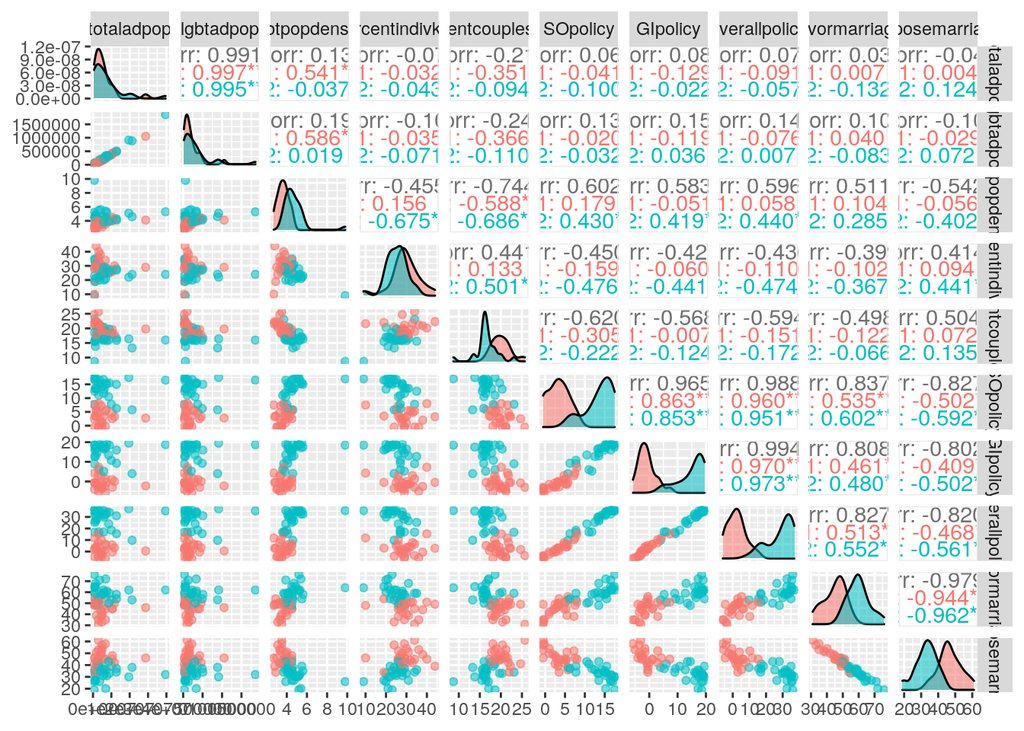

```r
ggpairs(lgbttest, aes(color = as.factor(pam1$clustering), alpha = 0.5))
```

*The silhouette demonstrates that 2 clusters is the best fit for this data set. The medoid of the first cluster has a lower totaladpop, lgbtadpop, lgbtpopdensity, SOpolicy, GI policy, overallpolicy, and favormarriage. The two medoids had equal percent of lgbt individuals with kids. The medoid of the second cluster had the lower percent of lgbt couples with kids. The first cluster is probably the republican cluster, while the second is probably the democrat cluster. The I find this interesting, since I would expect more adoptions to be restricted in states with low scores on the SOpolicy and GI policy. Though I think it might be due to the fact that these states might just have more of a value for having children. Looking at the plot there is a distinct difference between the states that votes republican and those that voted democrat within the SO policy, GI policy, and overall policy. Total adult population isn’t as distinct due to the fact that there are some states like Texas that have a high population but are republican. The plot also demonstrated that the red cluster (republican) have a higher percentage of LGBT couples with kids. As the SI policy score goes up, so does the GI policy score. The average silhouette width is .3682. This can be interpreted as a weak structure.*

### Dimensionality Reduction with PCA

```r
pca1 <- princomp(lgbttest, cor = T)
summary(pca1, loadings = T)
```

```
## Importance of components:
##                           Comp.1    Comp.2     Comp.3     Comp.4     Comp.5
## Standard deviation     2.3954046 1.4095350 0.96961673 0.79503279 0.62616829
## Proportion of Variance 0.5737963 0.1986789 0.09401566 0.06320771 0.03920867
## Cumulative Proportion  0.5737963 0.7724752 0.86649086 0.92969858 0.96890725
##                            Comp.6      Comp.7      Comp.8       Comp.9 Comp.10
## Standard deviation     0.50420309 0.177462359 0.139044173 0.0766849625       0
## Proportion of Variance 0.02542208 0.003149289 0.001933328 0.0005880583       0
## Cumulative Proportion  0.99432932 0.997478613 0.999411942 1.0000000000       1
##
## Loadings:
##                    Comp.1 Comp.2 Comp.3 Comp.4 Comp.5 Comp.6 Comp.7 Comp.8
## totaladpop                 0.691  0.133
## lgbtadpop           0.101  0.679  0.142
## lgbtpopdensity      0.307        -0.483 -0.386  0.203 -0.688
## percentindivkids   -0.234         0.540 -0.805
## percentcoupleskids -0.306 -0.118  0.465  0.410        -0.706
## SOpolicy            0.397         0.146        -0.321        -0.748 -0.180
## GIpolicy            0.390         0.192        -0.415 -0.104  0.608  0.126
## overallpolicy       0.396         0.175        -0.380
## favormarriage       0.370 -0.114  0.273  0.111  0.498        -0.122  0.701
## opposemarriage     -0.371  0.110 -0.242 -0.109 -0.534        -0.189  0.676
##                    Comp.9 Comp.10
## totaladpop          0.702
## lgbtadpop          -0.704
## lgbtpopdensity
## percentindivkids
## percentcoupleskids
## SOpolicy                  -0.332
## GIpolicy                  -0.484
## overallpolicy              0.809
## favormarriage
## opposemarriage
```

```r
pca2 <- pca1$scores %>% as.data.frame()
pca2
```

```
##        Comp.1     Comp.2      Comp.3      Comp.4      Comp.5     Comp.6
## 1  -3.5300027  0.2321546 -1.18062539  0.78217387 -0.71353734  0.1365582
## 2  -0.5679212 -1.4052135  1.70956972  0.04269700  0.50357936 -0.7573802
## 3  -0.2180292  0.3155321 -0.76179017  0.07566854  1.23258972  0.3992915
## 4  -3.9087175 -0.1476874 -0.07420026 -0.65064356 -0.11899806 -0.1457541
## 5   3.6667578  6.2213613  1.30062380  0.32115745 -0.26453702 -0.4680399
## 6   2.6505570 -0.5063033  0.38182314 -0.12603751 -0.43607975  0.2841017
## 7   2.9872040 -1.1571866  0.73878249  1.04079732  0.08757106  0.5980719
## 8   1.0471464 -1.1237325  0.49346782 -1.50317916 -0.01126492  0.4750996
## 9   5.6735728 -0.8149214 -4.48337221 -0.99510726  0.82894897 -1.2527485
## 10  0.6432433  3.0668529 -0.85754526 -0.13984909  0.71988102  0.9072946
##          Comp.7      Comp.8       Comp.9       Comp.10
## 1   0.199176043 -0.04115152 -0.011498676  7.256847e-16
## 2   0.147298931  0.06129737 -0.007902011 -3.462098e-16
## 3  -0.146918309 -0.04392153 -0.013063799 -5.977521e-16
## 4   0.091712651 -0.22393167 -0.044966824  3.496083e-16
## 5  -0.184067062  0.04307535 -0.259541690 -3.820854e-15
## 6  -0.019486338 -0.03121813  0.028581409  6.598529e-16
## 7   0.033530684  0.23173671  0.028145095 -2.178111e-16
## 8  -0.004209296  0.13879308 -0.044755975 -7.346195e-16
## 9   0.055432024 -0.03353445  0.034053661 -1.204983e-16
## 10  0.225518907 -0.04984150 -0.028176205  7.010917e-17
##  [ reached 'max' / getOption("max.print") -- omitted 41 rows ]
```

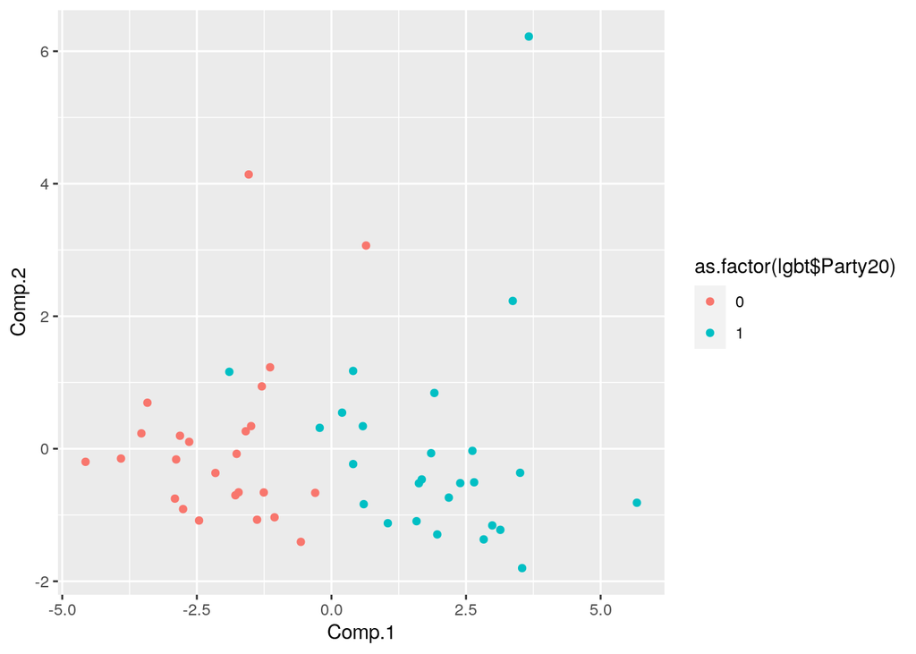

```r
pca2 %>% ggplot(aes(Comp.1, Comp.2, color = as.factor(lgbt$Party20))) +
    geom_point()
```

*The plot demonstrates that a republican voting state (0) most likely has a negative comp.1, while the blue democratic states (1) are more likely to have a positive Comp.1. There isn’t much distinction based on Comp.2. Most states are under 2 for Comp.2. A fr those that are above two its split between republican and democrat. Comp.1 and Comp.2 explain 0.7724752 oof the total variance in the dataset.*

### Linear Classifier

```r
set.seed(12)
fit <- glm(Party20 ~ lgbtpopdensity + percentcoupleskids + percentindivkids +
    SOpolicy + GIpolicy + favormarriage, data = lgbt, family = "binomial")

fit
```

```
##
## Call:  glm(formula = Party20 ~ lgbtpopdensity + percentcoupleskids +
##     percentindivkids + SOpolicy + GIpolicy + favormarriage, family = "binomial",
##     data = lgbt)
##
## Coefficients:
##        (Intercept)      lgbtpopdensity  percentcoupleskids    percentindivkids
##           -43.3614              8.0812              0.5867             -0.3840
##           SOpolicy            GIpolicy       favormarriage
##             0.6346              0.2020              0.0970
##
## Degrees of Freedom: 50 Total (i.e. Null);  44 Residual
## Null Deviance:       70.68
## Residual Deviance: 13.14     AIC: 27.14
```

```r
score <- predict(fit, type = "response")
score
```

```
##            1            2            3            4            5            6
## 1.546550e-06 3.765584e-01 8.874816e-01 1.113254e-07 1.000000e+00 9.999991e-01
##            7            8            9           10           11           12
## 9.999912e-01 9.929534e-01 1.000000e+00 8.805612e-01 3.732418e-01 9.998489e-01
##           13           14           15           16           17           18
## 1.802991e-08 9.998420e-01 2.663099e-01 3.579974e-01 3.329584e-04 2.189788e-03
##           19           20           21           22           23           24
## 9.878935e-04 1.000000e+00 9.999958e-01 1.000000e+00 8.182644e-01 9.990434e-01
##           25           26           27           28           29           30
## 1.720441e-05 2.098285e-03 9.524637e-04 4.431886e-03 1.000000e+00 9.999623e-01
##           31           32           33           34           35           36
## 9.999837e-01 9.997891e-01 1.000000e+00 7.014085e-02 8.057252e-02 5.549111e-02
##           37           38           39           40           41           42
## 4.773875e-05 1.000000e+00 4.514973e-01 9.999996e-01 1.241995e-05 6.502973e-07
##           43           44           45           46           47           48
## 1.346123e-06 1.808682e-02 3.914289e-03 1.000000e+00 8.580679e-01 9.999999e-01
##           49           50           51
## 3.965152e-03 4.942143e-01 1.152161e-03
```

```r
class_diag(score, truth = lgbt$Party20, positive = "1")
```

```
##            acc   sens spec    ppv   f1     ba    auc
## Metrics 0.9216 0.8846 0.96 0.9583 0.92 0.9223 0.9908
```

```r
# confusion matrix
y <- lgbt$Party20
y <- factor(y, levels = c(1, 0))
x <- score
# what is this x supposed to be?
yhat <- ifelse(x > 0.61, 1, 0)
yhat <- factor(yhat, levels = c(1, 0))
table(actual = y, predicted = yhat)
```

```
##       predicted
## actual  1  0
##      1 23  3
##      0  1 24
```

```r
# cross-validation of linear classifier here
set.seed(67)
k = 10
data <- lgbt[sample(nrow(lgbt)), ]  #randomly order rows
folds <- cut(1:nrow(lgbt), breaks = k, labels = F)
diags <- NULL

for (i in 1:k) {
    train <- data[folds != i, ]
    test <- data[folds == i, ]
    truth <- test$Party20
    fit <- glm(Party20 ~ percentcoupleskids + percentindivkids,
        data = train, family = "binomial")
    probs <- predict(fit, newdata = test, type = "response")
    diags <- rbind(diags, class_diag(probs, truth, positive = 1))
}
fit
```

```
##
## Call:  glm(formula = Party20 ~ percentcoupleskids + percentindivkids,
##     family = "binomial", data = train)
##
## Coefficients:
##        (Intercept)  percentcoupleskids    percentindivkids
##            18.6842             -0.8131             -0.1455
##
## Degrees of Freedom: 45 Total (i.e. Null);  43 Residual
## Null Deviance:       63.68
## Residual Deviance: 38.65     AIC: 44.65
```

```r
summarize_all(diags, mean)
```

```
##    acc    sens spec ppv      f1      ba     auc
## 1 0.84 0.79167  0.9 0.9 0.80239 0.84583 0.95833
```

```r
glimpse(lgbt)
```

```
## Rows: 51
## Columns: 12
## $ State              <chr> "alabama", "alaska", "arizona", "arkansas", "calif…
## $ totaladpop         <dbl> 4887871, 737438, 7171646, 3013825, 39557045, 56955…
## $ lgbtadpop          <dbl> 147000, 25000, 286000, 95000, 1859000, 234000, 133…
## $ lgbtpopdensity     <dbl> 3.1, 3.7, 4.5, 3.3, 5.3, 4.6, 3.9, 4.5, 9.8, 4.6, …
## $ percentindivkids   <dbl> 24, 34, 25, 36, 24, 25, 20, 35, 9, 24, 27, 30, 44,…
## $ percentcoupleskids <dbl> 20.4, 23.1, 16.5, 21.2, 16.0, 15.9, 17.0, 15.6, 8.…
## $ SOpolicy           <dbl> -0.50, 7.75, 5.75, -0.50, 16.50, 16.75, 16.50, 12.…
## $ GIpolicy           <dbl> -3.50, 9.00, -0.50, -5.00, 18.75, 18.75, 19.00, 12…
## $ overallpolicy      <dbl> -4.00, 16.75, 5.25, -5.50, 35.25, 35.50, 35.50, 25…
## $ favormarriage      <dbl> 33, 59, 56, 35, 62, 62, 71, 59, 64, 53, 45, 55, 49…
## $ opposemarriage     <dbl> 57, 34, 36, 53, 32, 31, 26, 36, 26, 38, 48, 33, 39…
## $ Party20            <dbl> 0, 0, 1, 0, 1, 1, 1, 1, 1, 0, 1, 1, 0, 1, 0, 0, 0,…
```

### Non-Parametric Classifier

```r
library(caret)
set.seed(1234)

fit <- knn3(lgbt$Party20 ~ lgbtpopdensity + percentcoupleskids +
    percentindivkids + SOpolicy + GIpolicy + favormarriage, data = lgbt)
probs <- predict(fit, newdata = lgbt)[, 2]
class_diag(probs, lgbt$Party20, positive = 1)
```

```
##            acc   sens spec    ppv     f1     ba    auc
## Metrics 0.9216 0.9231 0.92 0.9231 0.9231 0.9215 0.9731
```

```r
# confusion matrix
table(truth = lgbt$Party20, predictions = probs > 0.5)
```

```
##      predictions
## truth FALSE TRUE
##     0    23    2
##     1     2   24
```

```r
# cv of nonparametric
set.seed(1234)
k = 10
data <- lgbt[sample(nrow(lgbt)), ]  #randomly order rows
folds <- cut(1:nrow(lgbt), breaks = k, labels = F)
diags <- NULL

for (i in 1:k) {
    train <- data[folds != i, ]
    test <- data[folds == i, ]
    truth <- test$Party20
    # fit
    fit <- knn3(Party20 ~ lgbtpopdensity + percentcoupleskids +
        percentindivkids + SOpolicy + GIpolicy + favormarriage,
        data = train)

    probs <- predict(fit, newdata = test)[, 2]
    diags <- rbind(diags, class_diag(probs, truth, positive = 1))
}
summarize_all(diags, mean)
```

```
##       acc  sens spec     ppv      f1  ba   auc
## 1 0.90333 0.955  NaN 0.90834 0.92389 NaN 0.975
```

### Regression/Numeric Prediction

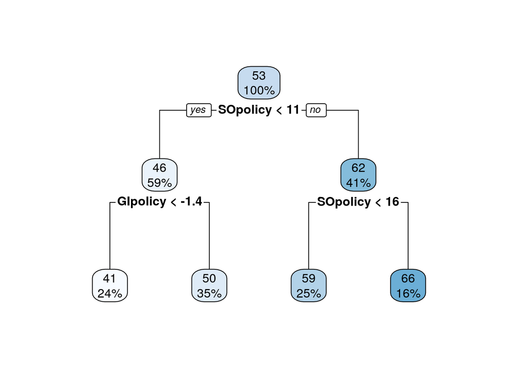

```r
# regression model code here
library(rpart)
library(rpart.plot)
fit <- rpart(favormarriage ~ lgbtpopdensity + percentcoupleskids +
    percentindivkids + SOpolicy + GIpolicy, data = lgbt)
rpart.plot(fit)
```

```r
pred1 <- predict(fit)
mean((lgbt$favormarriage - pred1)^2)
```

```
## [1] 26.85807
```

```r
set.seed(1234)
fit <- train(favormarriage ~ lgbtpopdensity + percentcoupleskids +
    percentindivkids + SOpolicy + GIpolicy, data = lgbt, method = "rpart")
fit$results$RMSE^2
```

```
## [1] 50.87426 56.77054 69.39256
```

```r
fit$bestTune
```

```
##           cp
## 1 0.04337573
```

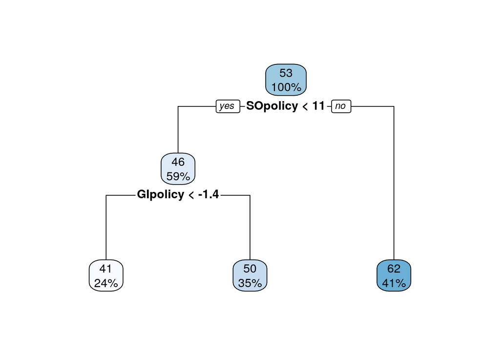

```r
rpart.plot(fit$finalModel)
```

```r
# cross-validation of regression model here
set.seed(1234)
k = 10
data <- lgbt[sample(nrow(lgbt)), ]  #randomly order rows
folds <- cut(1:nrow(lgbt), breaks = k, labels = F)
MSE <- NULL

for (i in 1:k) {
    train <- data[folds != i, ]
    test <- data[folds == i, ]
    truth <- test$favormarriage
    # fit
    fit <- rpart(favormarriage ~ lgbtpopdensity + percentcoupleskids +
        percentindivkids + SOpolicy + GIpolicy, data = train)
    pred <- predict(fit, newdata = test)
    MSE <- cbind(MSE, mean((truth - pred)^2))
}
mean(MSE)
```

```
## [1] 51.1926
```

avergae prediction score increased by a lot. from 26 to 51.

### Python

```r
library(reticulate)
use_python("usr/bin/python3")

hi <- "Happy"
```

```python
hi = "Holidays"
#print(r.hi,hi)
print(hi)
```

```
## Holidays
```

```r
cat(c(hi, py$hi))
```

```
## Happy Holidays
```